Skip to main content

# Initial death certificate analysis

Author

Sarah Cohen

Published

November 19, 2026

## Death overview

|  | Deaths | Facilities | Median age at death | Manner of death Natural | Manner of death Accident | Manner of death Homicide | Manner of death Pending or undetermined | Autopsy |  |
| --- | --- | --- | --- | --- | --- | --- | --- | --- | --- |
| RHA | 124 | 34 | 51 | 115 | 6 | 1 | 2 |  | 8 (6%) |
| Other private | 198 | 111 | 62 | 189 | 7 | 1 | 1 | 8 (4%) |  |
| Government | 161 | 1 | 69 | 154 | 7 | 0 | 0 | 4 (2%) |  |

Autopsy status was not recorded for 7 deaths.

## How serious were the causes listed?

Each death is placed at the highest level among all of the causes on its record. The levels flag records for a closer look; they are not findings of neglect.

- **3 Focused review:** commonly linked to lapses in supervision, feeding, hydration, skin care or safety (choking, falls, dehydration, bedsores)
- **2 Vigilance:** good monitoring and timely treatment often change the outcome (sepsis, pneumonia, seizures)
- **1 Expected:** chronic disease, cancer or end-of-life decline
- **0 Baseline:** only the person’s lifelong disability is listed

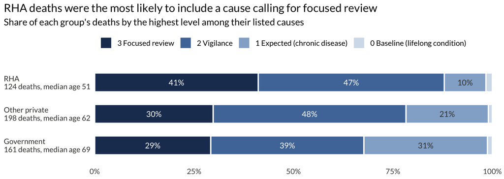

Deaths by highest level, count (share of column)

|  | RHA | Other private | Government | Total |
| --- | --- | --- | --- | --- |
| 3 Focused review | 51 (41%) | 59 (30%) | 47 (29%) | 157 (33%) |
| 2 Vigilance | 58 (47%) | 96 (48%) | 62 (39%) | 216 (45%) |
| 1 Expected (chronic disease) | 13 (10%) | 41 (21%) | 50 (31%) | 104 (22%) |
| 0 Baseline (lifelong condition) | 2 (2%) | 2 (1%) | 2 (1%) | 6 (1%) |
| Total | 124 (100%) | 198 (100%) | 161 (100%) | 483 (100%) |

Other data show that RHA reports serving residents with more severe disabilities

## Deaths calling for focused review

Every death with at least one level 3 cause. Search across all columns with the box at the top, filter within a column with the boxes under the headers, or click a header to sort. Click the arrow at the left of a row to see every cause listed on that death, from most to least serious. (A complete list is linked below)

Deaths with at least one cause calling for focused review

157 deaths in North Carolina ICFs, 2020 to 2026

| Group | Facility | Last name | Date of death | Age | Manner | Autopsy | Level 3 causes | Level 3 care areas | Official cause |
| --- | --- | --- | --- | --- | --- | --- | --- | --- | --- |
| Other private | BASS LAKE | LEONARD | 2026-03-21 | 70.5051334702259 | Natural | No | Severe malnutrition; Bedsore | Hydration/Nutrition; Skin Care/Wound | Urinary tract infection |
| Other private | LITTLE RIVER GROUP HOME | MORTON | 2026-02-26 | 82.403832991102 | Natural | No | Aspiration pneumonia; Choking on object | Swallowing/Aspiration | Epilepsy |
| Other private | WESTSIDE RESIDENTIAL | OXENDINE | 2026-02-18 | 62.4120465434634 | Natural | No | Malnutrition; Cause of death unknown | Hydration/Nutrition; Cause Undetermined | Malnutrition |
| RHA | CLEAR CREEK | EVANS | 2026-02-04 | 51.27446954141 | Natural | No | Choking; Choking on food | Swallowing/Aspiration | Sepsis, germ unknown |
| RHA | CLEAR CREEK | NELSON | 2026-01-15 | 54.9514031485284 | Natural | No | Cause of death unknown | Cause Undetermined | Sepsis, germ unknown |
| Government | North Carolina | RITCHIE | 2025-12-29 | 49.7303216974675 | Natural | No | Aspiration pneumonia; Choking on object | Swallowing/Aspiration | Aspiration pneumonia |
| Other private | VOCA - NORWICH ROAD GROUP HOME | WILLIS | 2025-12-28 | 63.7234770704997 | Natural | No | Malnutrition; Bedsore | Hydration/Nutrition; Skin Care/Wound | Malnutrition |
| Other private | HILLTOP HOME | HUNT | 2025-12-02 | 8 | Natural | No | Choking; Choking on object | Swallowing/Aspiration | Viral infection, unspecified |
| RHA | RIVERBEND | LEWIS | 2025-11-30 | 50.466803559206 | Natural | No | Constipation | Bowel/Bladder Care | Cerebral palsy |
| Other private | VOCA - KIMSEY | PAINTER | 2025-11-29 | 40.4106776180698 | Pending | Yes | Cause of death unknown | Cause Undetermined | Cause of death unknown |

[output cut: 147 more lines]

Source: N.C. death certificate records; cause-of-death levels assigned by the project team.

## Download the data

[Download the full spreadsheet (Excel)](https://docs.google.com/spreadsheets/d/1rnzBfH_HJdtZXzlkmqerwrVyiDNlp1q-/edit?usp=drive_link&ouid=109144084184131668758&rtpof=true&sd=true)

The workbook has four sheets:

- **Deaths:** every death in the original combined file, one row each, with the coding columns added at the right
- **Causes:** one row for each cause listed on each death, with its plain-language label, care area and level
- **Code lookup:** every cause code in the data with its definition, care area and level
- **About:** what the levels and flags mean